# 02-manifold_excursion

Corson N. Areshenkoff

18/03/2022

## Required packages

```r
library(zoo)
library(plyr)
library(ggplot2)

# For computing generalized inverses
library(MASS)

# Used for functional PCA
library(fda)
```

## Data

The file `data/guides/example_data.rds` contains example BOLD data from 4 subjects, each with rest and task scans. The data are stored in a dataframe with columns for `Subject`, `Scan`, and `Data`; the latter containing TR x ROI matrices of (standardized) BOLD data.

```r
df <- readRDS('../data/example_data.rds')
```

## Excursion

Our measure of excursion is calculated first by estimating a subspace capturing the dominant patterns of variability in a subject’s resting state BOLD data, and then by computing, at each imaging volume, the distance between task BOLD activation and the resting state manifold.

### Workflow for a single subject

We experimented with several methods for estimating the dimension of a subject’s resting state manifold, all with similar results, and so we follow the manuscript and select enough components to account for 75% of the resting state BOLD variability.

```r
resting.state <- subset(df, Scan == 'Rest' & Subject == 'S1')$Data[[1]]
fit.svd <- svd(resting.state)

# Examine variance explained by each singular vector
eigs      <- fit.svd$d^2
var.exp   <- cumsum(eigs)/sum(eigs)
dimension <- min(which(var.exp >= .75))

# Extract the leading right singular vectors, giving a basis for the resting
# state subspace
V <- fit.svd$v[,1:dimension]
```

We then separate the on- and off-manifold components of the task BOLD signal by projecting each BOLD activation vector onto, respectively, the subspace spanned by V, and it’s orthogonal complement.

```r
# Projection matrix for the subspace spanned by V
P.on <- V %*% ginv(t(V) %*% V) %*% t(V)

# Projection onto the orthogonal complement
I <- diag(nrow(V))
P.off <- I - V %*% ginv(t(V) %*% V) %*% t(V)

# On- and off- manifold projection of the task BOLD signal
bold.data <- subset(df, Scan == 'Task' & Subject == 'S1')$Data[[1]]
bold.on.manifold  <- bold.data %*% P.on
bold.off.manifold <- bold.data %*% P.off
```

We define the “off-manifold activation” to be the norm of the off-manifold component. Because this is confounded with the overall magnitude of the BOLD activation vector (that is, for a fixed pattern of BOLD activation, scaling the entire activation vector by a constant will change the on- and off-manifold activation), we define the “excursion” to be the proportion of the total activation which is off-manifold.

```r
activation.on  <- apply(bold.on.manifold,  1, function(i) sqrt(sum(i^2)))
activation.off <- apply(bold.off.manifold, 1, function(i) sqrt(sum(i^2)))
excursion <- activation.off / (activation.on + activation.off)
```

We then standardize the excursion with respect to the baseline phase of the task (in this case, the first 240 imaging volumes).

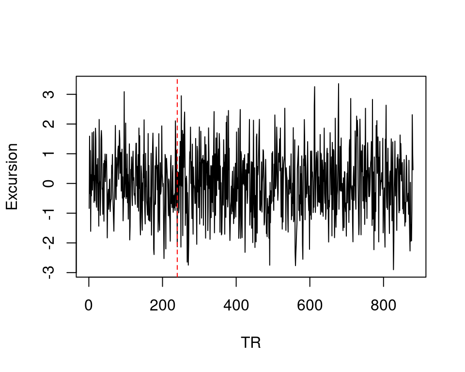

```r
excursion.std <- (excursion - mean(excursion[1:240]))/sd(excursion[1:240])
plot(excursion.std, type = 'l', xlab = 'TR', ylab = 'Excursion')
abline(v = 240, col = 'red', lty = 2)
```

### Excursion for all subjects

```r
ComputeExcursion <- function(resting.state, bold.data) {

    # Resting state basis
    fit.svd <- svd(resting.state)
    eigs      <- fit.svd$d^2
    var.exp   <- cumsum(eigs)/sum(eigs)
    dimension <- min(which(var.exp >= .75))
    V <- fit.svd$v[,1:dimension]

    # Projection matrix for the subspace spanned by V
    P.on <- V %*% ginv(t(V) %*% V) %*% t(V)

    # Projection onto the orthogonal complement
    I <- diag(nrow(V))
    P.off <- I - V %*% ginv(t(V) %*% V) %*% t(V)

    # On- and off- manifold projection of the task BOLD signal
    bold.on.manifold  <- bold.data %*% P.on
    bold.off.manifold <- bold.data %*% P.off

    activation.on  <- apply(bold.on.manifold,  1, function(i) sqrt(sum(i^2)))
    activation.off <- apply(bold.off.manifold, 1, function(i) sqrt(sum(i^2)))
    excursion <- activation.off / (activation.on + activation.off)
    excursion.std <- (excursion - mean(excursion[1:240]))/sd(excursion[1:240])

    return(excursion.std)

}

df.exc <- ddply(df, 'Subject', summarize,
                'Excursion' =
                    ComputeExcursion(Data[[which(Scan == 'Rest')]],
                                     Data[[which(Scan == 'Task')]]))
```

For consistency with the behavioral data, we then average the excursion over bins of 16 TRs (corresponding to 8 trials).

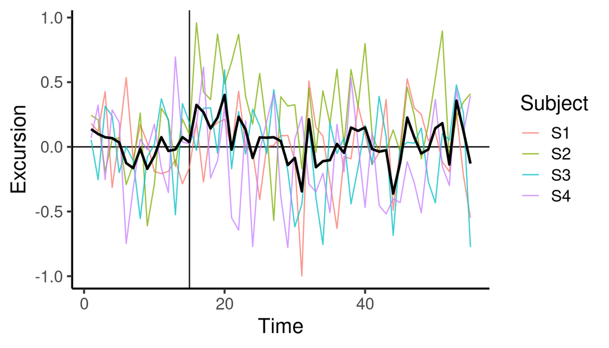

```r
df.exc <- ddply(df.exc, 'Subject', summarize,
                'Time' = 1:(length(Excursion)/16),
                'Excursion' = rollapply(Excursion, width = 16, by = 16,
                                        FUN = mean, align = 'left'))

ggplot(df.exc, aes(x = Time, y = Excursion, group = Subject, color = Subject)) +
    theme_classic(base_size = 17) +
    geom_hline(yintercept = 0) + geom_vline(xintercept = 15) +
    geom_line(alpha = .75) +
    stat_summary(fun = mean, group = -1, geom = 'line', size = 1, color = 'black')
```

### Functional PCA

The full manuscript involves a multivariate functional PCA over both days and both networks. In this example, with only a single excursion trajectory per subject, we conduct a standard univariate fPCA using the `fda` package.

```r
# Assemble a time x subject matrix of excursion trajectories
excursion.data <- sapply(unique(df.exc$Subject), function(s)
    subset(df.exc, Subject == s)$Excursion)

# Create a functional data object
# This requires the specification of timestamps for each observation (row) in
# excursion.data. In this case, it will make no difference what we choose, but
# note that it is often easier to manually tune smoothing parameters if the
# time is normalized to the interval (0,1).
#
# Depending on the specific research problem, the user may want to manually
# specify a set of basis functions. In our case, we'll use the default for
# Data2fd(), which is a cubic spline basis with knots at each observation, and
# smoothing penalty selected by generalized cross validation.
argvals <- 1:nrow(excursion.data)
excursion.fd <- Data2fd(argvals, excursion.data)
fit.fpca <- pca.fd(excursion.fd, nharm = 2, centerfns = T)
```

The default visualization of the components, using `plot(fit.fpca)`, isn’t particularly clear. We can evaluate the functional data objects to obtain the actual numeric values and create our own figures. Note that, with only four subjects and very little smoothing, we can expect the components to be extremely noisy.

```r
mean.function <- eval.fd(argvals, fit.fpca$meanfd)
components    <- eval.fd(argvals, fit.fpca$harmonics)
n.time  <- nrow(mean.function)
n.comps <- ncol(components)

df.fpca <- data.frame(Component = rep(paste('fPC', 1:n.comps), each = n.time),
                      Time = 1:n.time, Excursion = as.numeric(mean.function),
                      Loading = as.numeric(components))
```

In the manuscript, we plot the components as shaded bands around the mean function, where each colorband denotes an increase (or decrease) of a standard deviation from the mean score. So if the mean score on component 1 were S, then the first colorband would be at `mean + S*loading`, and the second would be at `mean + 2*S*loading`, and so forth. In this example, with only four subjects, we manually specify the bands to display a reasonable range of values.

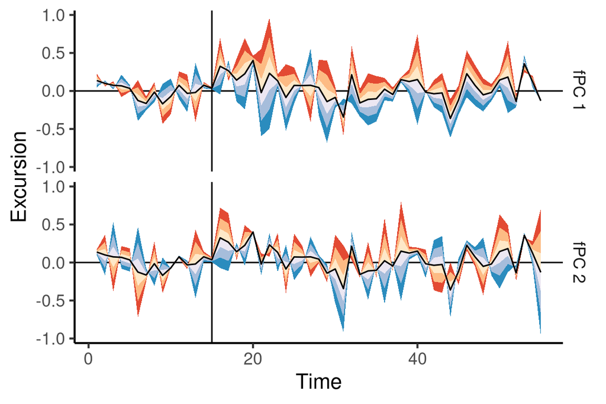

```r
ggplot(df.fpca, aes(x = Time, y = Excursion)) +
    facet_grid(Component ~ .) +
    theme_classic(base_size = 15) +

    geom_vline(xintercept = 15) +
    geom_hline(yintercept = 0) +

    geom_ribbon(aes(ymin = Excursion, ymax = Excursion + 2*Loading),
                fill = "#e34a33") +
    geom_ribbon(aes(ymin = Excursion, ymax = Excursion + 1.3*Loading),
                fill = "#fdbb84") +
    geom_ribbon(aes(ymin = Excursion, ymax = Excursion + .6*Loading),
                fill = "#fee8c8") +

    geom_ribbon(aes(ymin = Excursion, ymax = Excursion - 2*Loading),
                fill = "#2b8cbe") +
    geom_ribbon(aes(ymin = Excursion, ymax = Excursion - 1.3*Loading),
                fill = "#a6bddb") +
    geom_ribbon(aes(ymin = Excursion, ymax = Excursion - .6*Loading),
                fill = "#ece7f2") +
    geom_line(color = 'black') +

    theme(strip.background = element_rect(color = 'white', fill = 'white'),
          legend.position = 'none')
```

Notice that the first component seems to indicate the overall level of excursiion post-rotation, with positive scores (red) indicating more overall excursion than average, and negative scores (blue) indicating less than average excursion. The second component is noisier and less obviously interpretable, which is to be expected given the small sample size in this example dataset.

Referring back to the second figure, showing the excursion for each subject, we notice that subject S2 (in green) has greater excursion than the other subjects. We would then expect them to have a *higher* score on the first component. We can confirm this by plotting the component scores for each subject:

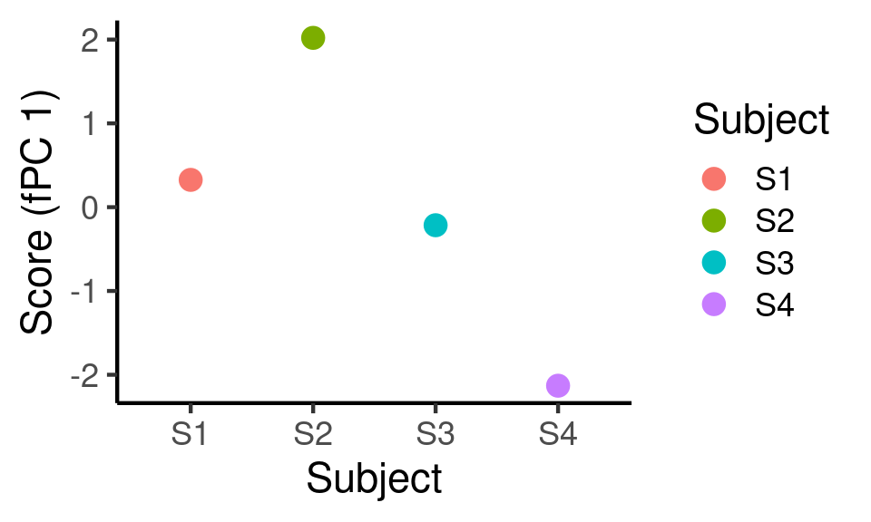

```r
df.scores <- data.frame(Subject = unique(df$Subject),
                        Score = fit.fpca$scores[,1])
ggplot(df.scores, aes(x = Subject, y = Score, color = Subject)) +
    theme_classic(base_size = 17) +
    geom_point(size = 4) +
    ylab('Score (fPC 1)')
```

This confirms what we can see in the second figure: Subject 2 has the greatest overall excursion post-rotation, while Subject 4 has the least.